# Consensus mapping for the immune atlas

Authors

Affiliations

[Dharmesh D. Bhuva](https://bhuvad.github.io/)

SAiGENCI, The University of Adelaide

South Australian Health and Medical Research Institute (SAHMRI)

Walter and Eliza Hall Institute

Stefano Mangiola

SAiGENCI, The University of Adelaide

Walter and Eliza Hall Institute

Published

October 24, 2024

Abstract

Power analysis

# Load data

| cell_ | observation_joinid | cell_type | cell_type_ontology_term_id | dataset_id | self_reported_ethnicity | tissue | donor_id | sample_id | is_primary_data | assay | nFeature_RNA | empty_droplet | blueprint_first_labels_fine | monaco_first_labels_fine | scores.Macrophages | scores.Macrophages.M1 | scores.Macrophages.M2 | scores.Naive.CD4.T.cells | scores.Terminal.effector.CD4.T.cells | scores.CD4..T.cells | scores.CD4..Tcm | scores.CD4..Tem | scores.Follicular.helper.T.cells | scores.Th1.cells | scores.Th1.Th17.cells | scores.Th17.cells | scores.Th2.cells | azimuth_predicted_celltype_l2 |
| --- | --- | --- | --- | --- | --- | --- | --- | --- | --- | --- | --- | --- | --- | --- | --- | --- | --- | --- | --- | --- | --- | --- | --- | --- | --- | --- | --- | --- |
| GCTTTCGCAGACTGCC-L8TX_210527_01_F06-1108850816___6f7fd0f1-a2ed-4ff1-80d3-33dde731cbc3 | df$zxid{Tq | oligodendrocyte | CL:0000128 | 6f7fd0f1-a2ed-4ff1-80d3-33dde731cbc3 | European | dorsolateral prefrontal cortex | H20.33.024 | 48588c94c170c7a01b30849b671c0b94___-L8TX_210527_01_F06-1108850816 | TRUE | 10x 3' v3 | 1825 | FALSE | Neurons | Myeloid dendritic cells | 0.0362442456 | 2.741456e-02 | 0.051229554 | 0.07591778 | 0.06653209 | 0.06250442 | 0.042392236 | 0.035452073 | 0.07119759 | 0.07122519 | 0.07729545 | 0.08184376 | 0.07667141 | CD4 TCM |
| GTAAGTCGTCTACGTA-L8TX_210603_01_B10-1109152712___6f7fd0f1-a2ed-4ff1-80d3-33dde731cbc3 | z4Ul%-j>#r | L2/3-6 intratelencephalic projecting glutamatergic neuron | CL:4023040 | 6f7fd0f1-a2ed-4ff1-80d3-33dde731cbc3 | European | dorsolateral prefrontal cortex | H20.33.013 | 33ba8d6728a183f6145cc447ae988648___-L8TX_210603_01_B10-1109152712 | TRUE | 10x 3' v3 | 5859 | FALSE | Neurons | Plasmacytoid dendritic cells | 0.0882662940 | 6.473977e-02 | 0.115251558 | 0.13151671 | 0.12559082 | 0.16517892 | 0.127518393 | 0.112878735 | 0.11613656 | 0.11680977 | 0.13550592 | 0.12380753 | 0.12936419 | HSPC |
| ACGTACAAGCATAGGC-L8TX_220217_01_B06-1162250579___6f7fd0f1-a2ed-4ff1-80d3-33dde731cbc3 | _u7yL;Sy;4 | astrocyte of the cerebral cortex | CL:0002605 | 6f7fd0f1-a2ed-4ff1-80d3-33dde731cbc3 | European | dorsolateral prefrontal cortex | H20.33.028 | 070d9117ec508d58550f59ae00a8ff8d | TRUE | 10x 3' v3 | 4780 | FALSE | Neurons | Plasmacytoid dendritic cells | 0.0742054945 | 5.829934e-02 | 0.105593060 | 0.11325037 | 0.11656334 | 0.10692786 | 0.064936004 | 0.049095820 | 0.10506655 | 0.10432171 | 0.11521025 | 0.11082083 | 0.10931826 | HSPC |
| AGGGCTCCAAGTTCCA-L8TX_220120_02_C03-1155539600___6f7fd0f1-a2ed-4ff1-80d3-33dde731cbc3 | O9fim9Y~RG | astrocyte of the cerebral cortex | CL:0002605 | 6f7fd0f1-a2ed-4ff1-80d3-33dde731cbc3 | European | dorsolateral prefrontal cortex | H21.33.002 | 2a8fc87d0dd3d9394dfb256c1540e141___-L8TX_220120_02_C03-1155539600 | TRUE | 10x 3' v3 | 4850 | FALSE | Neurons | Plasmacytoid dendritic cells | 0.0662206644 | 4.942220e-02 | 0.099800928 | 0.12256899 | 0.12696456 | 0.10218768 | 0.077093211 | 0.063556663 | 0.11759736 | 0.11555734 | 0.12713753 | 0.12414016 | 0.12307862 | NA |
| AGCCAATAGCGCTTCG-L8TX_210812_01_F10-1124416551___6f7fd0f1-a2ed-4ff1-80d3-33dde731cbc3 | zB&0?*XYd@ | L2/3-6 intratelencephalic projecting glutamatergic neuron | CL:4023040 | 6f7fd0f1-a2ed-4ff1-80d3-33dde731cbc3 | European | dorsolateral prefrontal cortex | H21.33.018 | f77ae49916074461405c99a4bb77ad90___-L8TX_210812_01_F10-1124416551 | TRUE | 10x 3' v3 | 5354 | FALSE | Neurons | Plasmacytoid dendritic cells | 0.0770635364 | 5.652719e-02 | 0.092164097 | 0.13123876 | 0.13552286 | 0.14538934 | 0.126200589 | 0.118151329 | 0.12249620 | 0.12547146 | 0.15230704 | 0.14027615 | 0.12784860 | HSPC |
| CGCCAGACAGCTATAC-L8TX_210826_01_A05-1127603909___6f7fd0f1-a2ed-4ff1-80d3-33dde731cbc3 | +JbO^+t-?5 | L2/3-6 intratelencephalic projecting glutamatergic neuron | CL:4023040 | 6f7fd0f1-a2ed-4ff1-80d3-33dde731cbc3 | European | dorsolateral prefrontal cortex | H21.33.022 | a8b4ee5448439d8840d9af9d2eb95283___-L8TX_210826_01_A05-1127603909 | TRUE | 10x 3' v3 | 10108 | FALSE | Neurons | Plasmacytoid dendritic cells | 0.1403281490 | 1.194093e-01 | 0.171689225 | 0.17210711 | 0.16587032 | 0.24339698 | 0.201154887 | 0.185367982 | 0.15898558 | 0.15970298 | 0.17963036 | 0.17406871 | 0.17235870 | HSPC |
| TACCTCGTCTCTCTAA-L8TX_210916_01_C04-1131593672___6f7fd0f1-a2ed-4ff1-80d3-33dde731cbc3 | B;OzV534K{ | microglial cell | CL:0000129 | 6f7fd0f1-a2ed-4ff1-80d3-33dde731cbc3 | European | dorsolateral prefrontal cortex | H21.33.040 | 4166d379c9742634d818aa0e30016cc2___-L8TX_210916_01_C04-1131593672 | TRUE | 10x 3' v3 | 4586 | FALSE | Macrophages | Intermediate monocytes | 0.3793958495 | 3.333411e-01 | 0.328826083 | 0.14601476 | 0.17123204 | 0.24590896 | 0.222123027 | 0.215150503 | 0.13270217 | 0.14088941 | 0.14696237 | 0.13865972 | 0.14208858 | B intermediate |
| TGTTGGATCAGCGCGT-L8TX_200213_01_G05-1027251032___6f7fd0f1-a2ed-4ff1-80d3-33dde731cbc3 | 17>jKfFCb+ | L2/3-6 intratelencephalic projecting glutamatergic neuron | CL:4023040 | 6f7fd0f1-a2ed-4ff1-80d3-33dde731cbc3 | European | dorsolateral prefrontal cortex | H19.30.001 | f2e5e126d41885e9836f8735e6ca81f3___-L8TX_200213_01_G05-1027251032 | TRUE | 10x 3' v3 | 6240 | FALSE | Neurons | Plasmacytoid dendritic cells | 0.0866958188 | 7.141590e-02 | 0.116898843 | 0.11910674 | 0.11036419 | 0.16268460 | 0.124336788 | 0.114425429 | 0.10427109 | 0.10490438 | 0.11618540 | 0.11220763 | 0.11161864 | NA |
| GATGTTGAGAGGGCGA-L8TX_211124_01_D03-1144726144___6f7fd0f1-a2ed-4ff1-80d3-33dde731cbc3 | g-aw`r#El# | pvalb GABAergic cortical interneuron | CL:4023018 | 6f7fd0f1-a2ed-4ff1-80d3-33dde731cbc3 | European | dorsolateral prefrontal cortex | H21.33.046 | 367b366d2cc37c955d57abaf5198cdb9 | TRUE | 10x 3' v3 | 36291 | FALSE | Neurons | Plasmacytoid dendritic cells | 0.0561638965 | 3.384409e-02 | 0.082018222 | 0.13694000 | 0.12949438 | 0.14062634 | 0.101328373 | 0.082315346 | 0.12177802 | 0.11798669 | 0.13251194 | 0.13667284 | 0.13437208 | NA |
| AGGTGTTCATCGAGCC-L8TX_210916_01_G04-1131590418___6f7fd0f1-a2ed-4ff1-80d3-33dde731cbc3 | L+Tn_r1Olr | sncg GABAergic cortical interneuron | CL:4023015 | 6f7fd0f1-a2ed-4ff1-80d3-33dde731cbc3 | European | dorsolateral prefrontal cortex | H21.33.015 | 3107c253045805dcda4e382aa60524af___-L8TX_210916_01_G04-1131590418 | TRUE | 10x 3' v3 | 7044 | FALSE | Neurons | Plasmacytoid dendritic cells | 0.0759210163 | 6.014099e-02 | 0.102691266 | 0.12337094 | 0.12334846 | 0.14150665 | 0.099957224 | 0.085178704 | 0.10603799 | 0.10167311 | 0.12075281 | 0.11546012 | 0.11390064 | HSPC |

[output cut: 990 more lines]

# Compute data-driven consensus

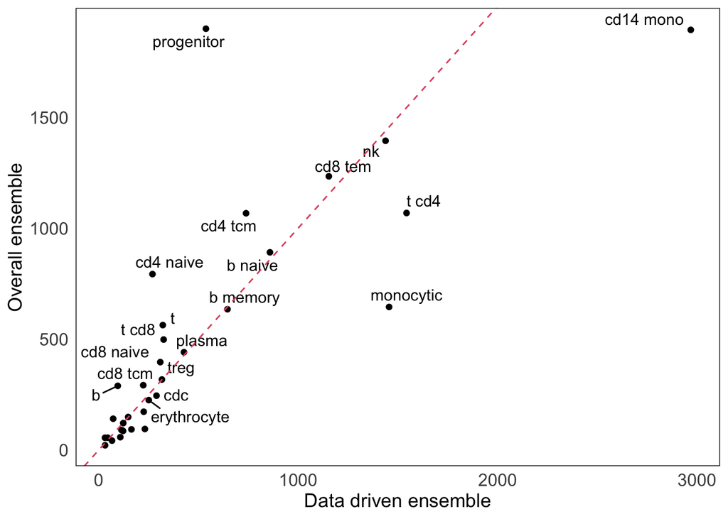

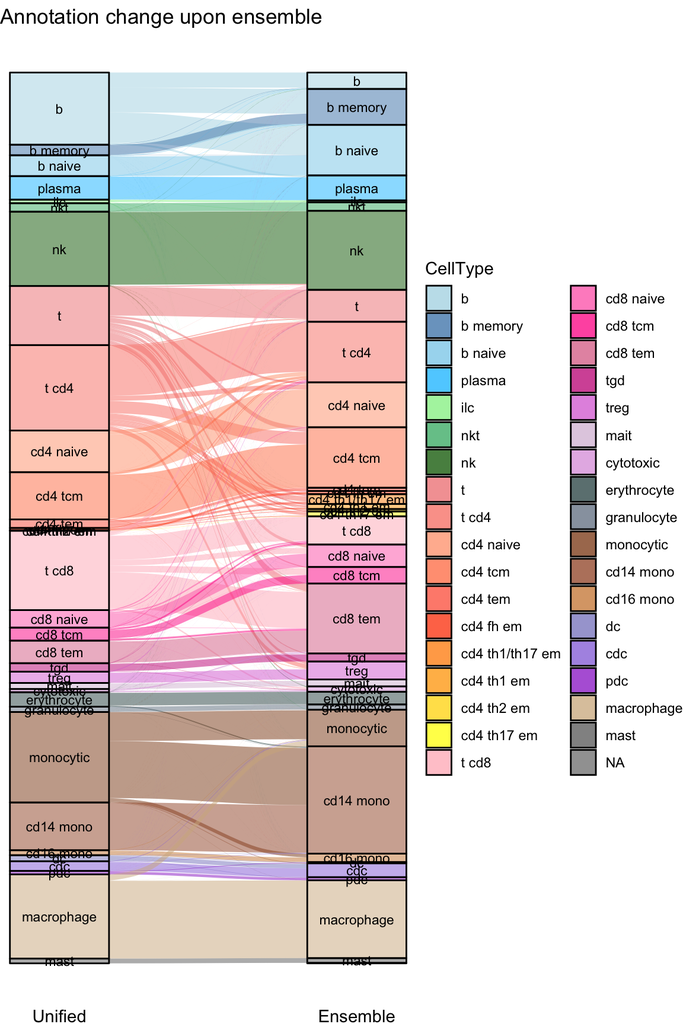

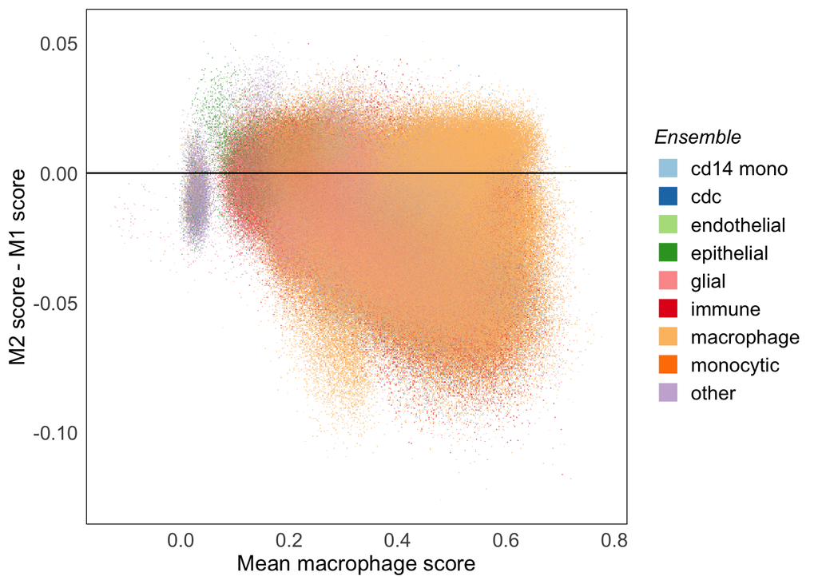

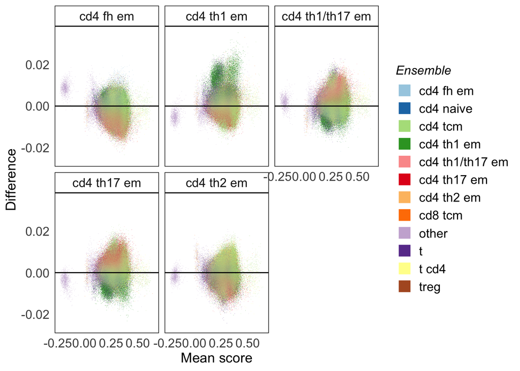

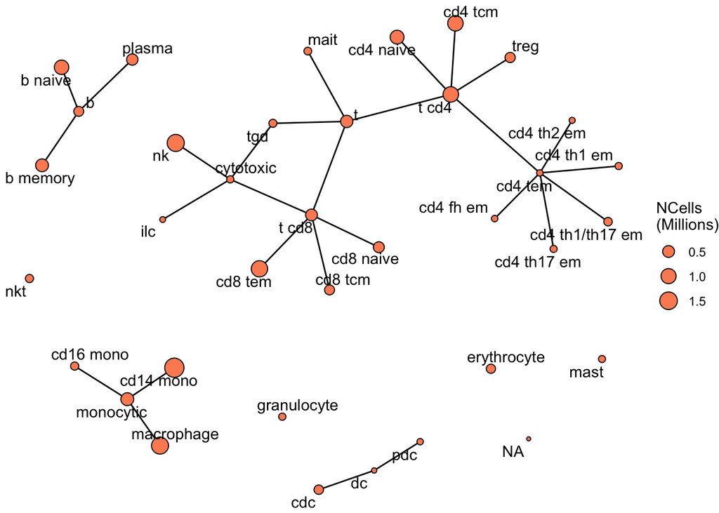

# Cell types mapped

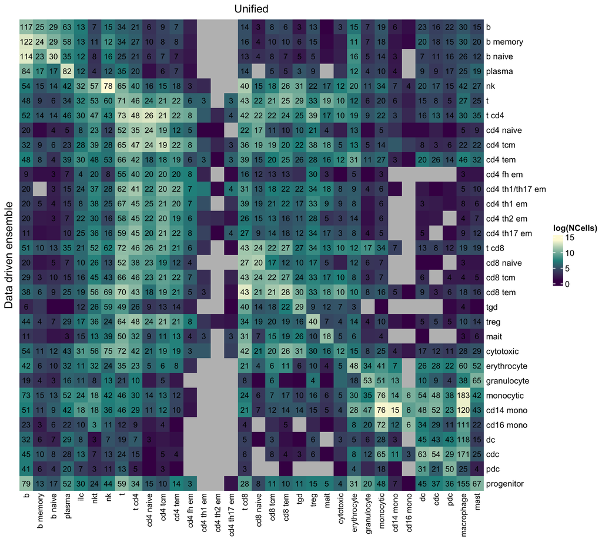

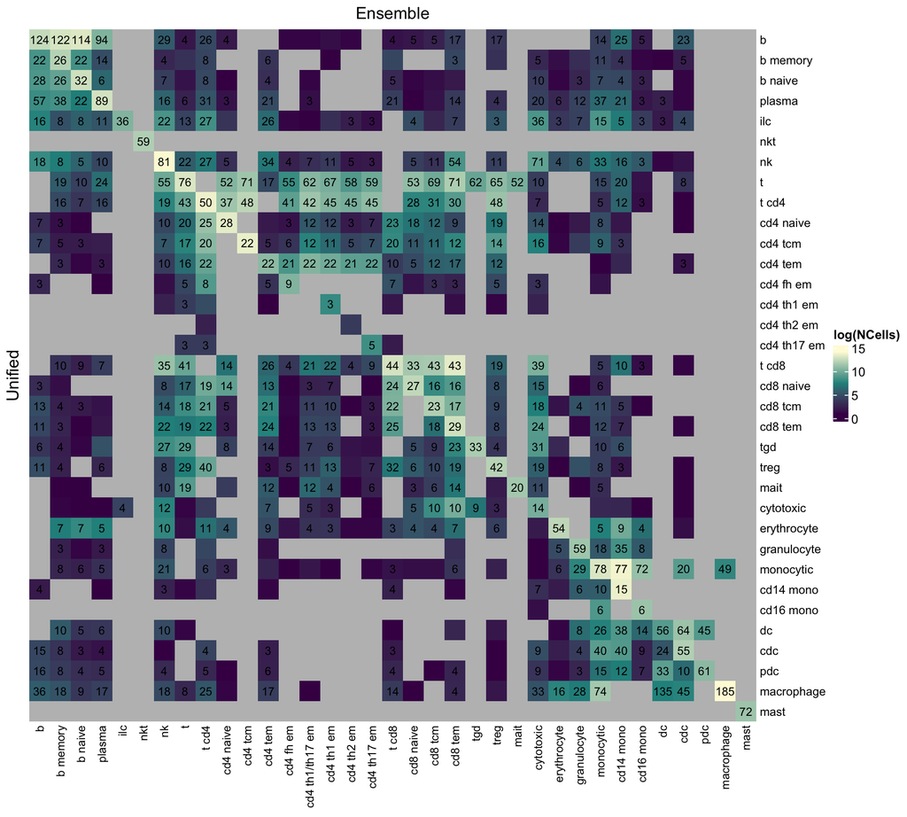

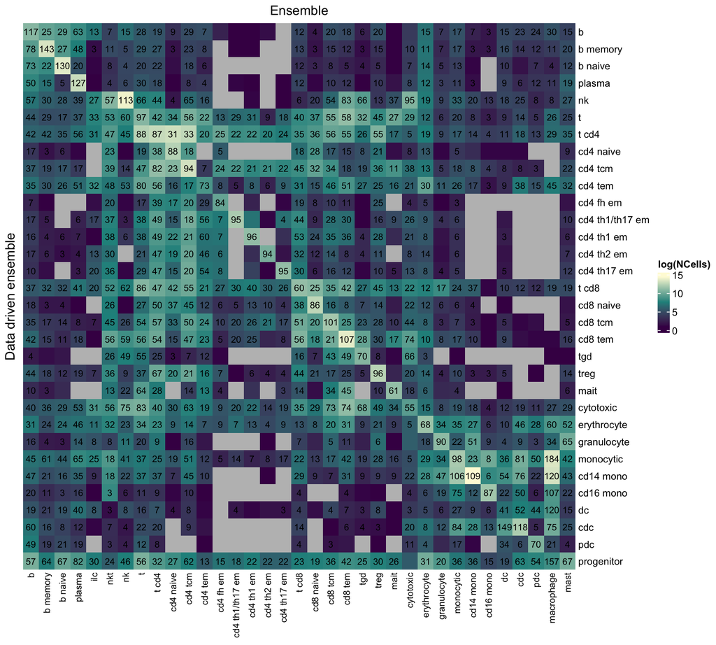

# Mapping summaries

Here we break the links from cytotoxic cells to other cytotoxic cell types such as nk, ilc, tgd, and t cd8. These are useful for retaining higher level annotations but we want them to be an independent tree for the purposes of determining depth of annotation.

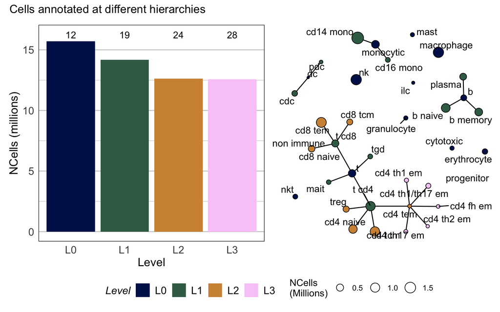

# Resolving missing values at deeper annotation levels

Some cells will have missing annotations at specific levels. This is because neither the original annotation, nor our annotation were able to further resolve their type in the cell type hierarcy. This can happen in three possible scenarios:

1. Annotation is missing using one approach and the other is only able to provide a high level annotation.
2. The low level annotation is the best possible using both approaches (one might have a higher level annotation).
3. Cell types called using both approaches end up being siblings therefore the parent annotation is the best we can achieve.

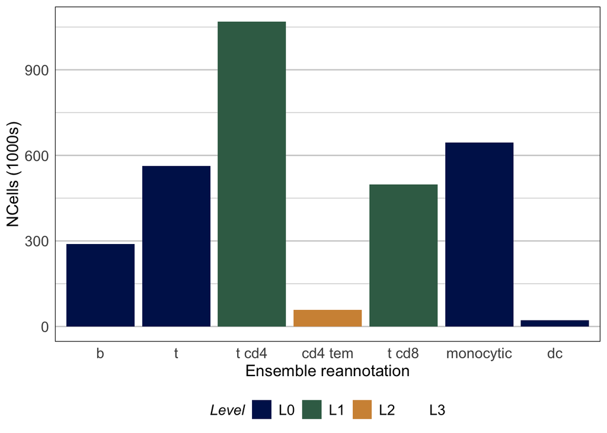

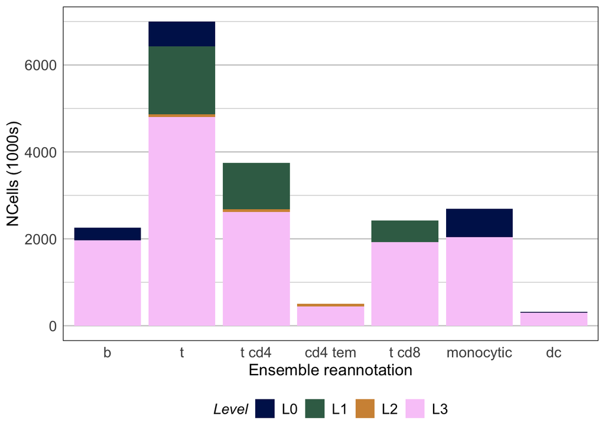

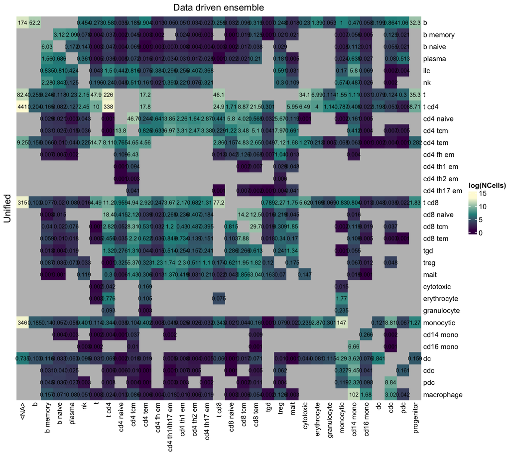

```
# A tibble: 31 × 3
   cell_type_unified cell_type_unified_ensemble  NCells
   <chr>             <chr>                        <dbl>
 1 other             other                      2039871
 2 macrophage        other                        72296
 3 ilc               other                        21110
 4 t                 other                        19562
 5 t cd4             other                        15339
 6 nk                other                        10242
 7 cd8 tcm           other                         7332
 8 plasma            other                         6629
 9 mast              other                         6544
10 monocytic         other                         6314
11 treg              other                         5957
12 cd4 naive         other                         5573
```

[output cut: 19 more lines]

# Dataset summaries

## Summary per dataset

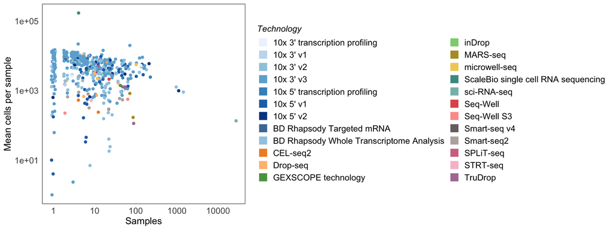

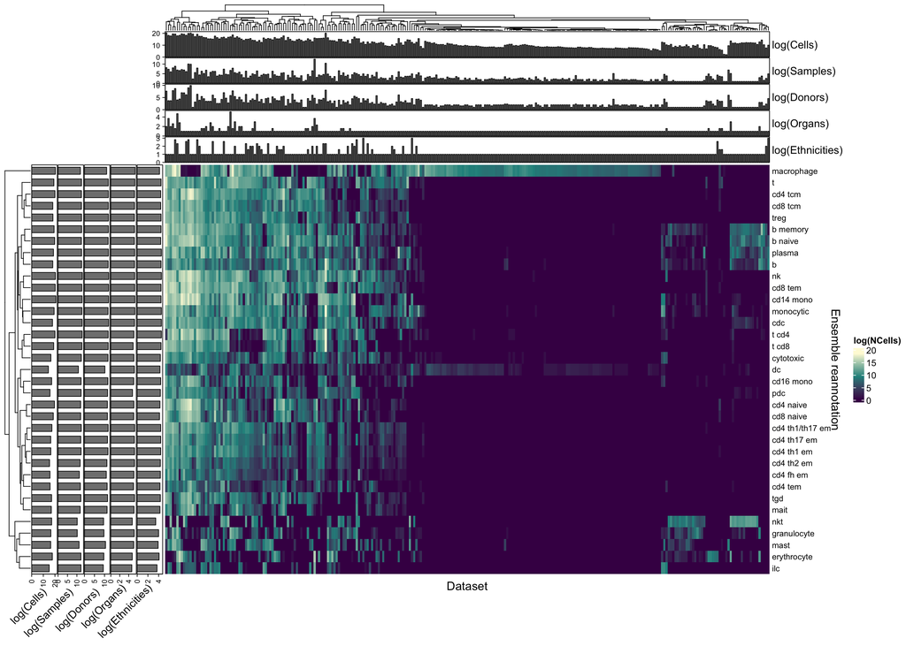

## Summary per organ

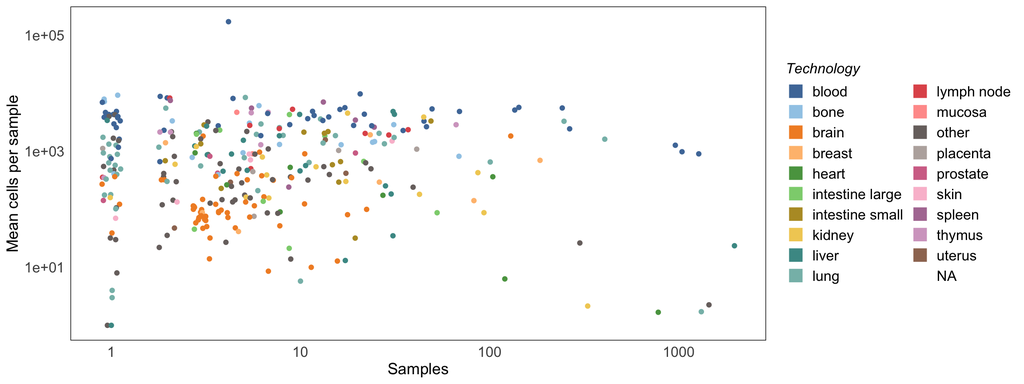

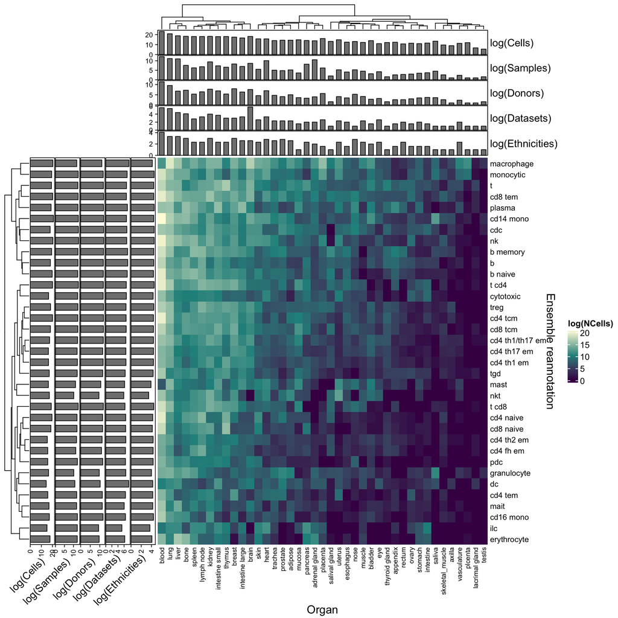